Leukemia Research 97 (2020) 106442

Available online 27 August 2020

0145-2126/© 2020 Elsevier Ltd. All rights reserved.

Research paper

Plerixafor in combination with chemotherapy and/or hematopoietic cell

transplantation to treat acute leukemia: A systematic review and

metanalysis of preclinical and clinical studies

Harinad Maganti <sup>a</sup><sup>,</sup><sup>1</sup>, Alissa Visram <sup>b</sup><sup>,</sup><sup>1</sup>, Risa Shorr <sup>c</sup>, Jill Fulcher <sup>a</sup><sup>,</sup><sup>b</sup>, Mitchell Sabloff <sup>a</sup><sup>,</sup><sup>b</sup>,

David S. Allan <sup>a</sup><sup>,</sup><sup>b</sup><sup>,</sup>*

a *Clinical Epidemiology Program, Ottawa Hospital Research Institute, Canada*

b *Department of Medicine (Hematology), Faculty of Medicine, University of Ottawa, Canada*

c *Medical Library, The Ottawa Hospital, Ottawa, Canada*

A R T I C L E I N F O

*Keywords:*

Plerixafor

Acute leukemia

Chemotherapy

Hematopoietic cell transplantation

Stem cell niche

A B S T R A C T

Leukemia-initiating cells localize to bone marrow niches via cell surface CXCR4 binding to stromal-derived factor

1 (SDF-1). Plerixafor, a CXCR4 antagonist, can mobilize and sensitize leukemia cells to cytotoxic therapy, and/or

enhance the engraftment of healthy donor stem cells in the context of hematopoietic cell transplantation (HCT).

A systematic review of preclinical and clinical studies was performed (updated May 1, 2020) to inform the design

of definitive clinical trials and identified 19 studies. Pooled data from 10 preclinical *in-vivo* studies of AML and

ALL in mouse models of leukemia revealed significant mobilization of leukemia cells into the peripheral circu-

lation, decreased total blast burden and increased survival with plerixafor in addition to cytotoxic treatment

compared to control animals. Two of 9 clinical studies compared outcomes to a control group. Plerixafor appears

well tolerated and safe and can mobilize leukemia cells into the peripheral circulation. In patients with AML

undergoing HCT, plerixafor given with the conditioning regimen appears safe and well tolerated. Engraftment,

relapse and survival were not different from controls after limited follow-up. Studies in high risk patients with

AML with longer follow-up are needed to understand the influence on relapse following treatment and on donor

cell engraftment following HCT.

**1. Introduction**

Acute myeloid leukemia (AML) and acute lymphoblastic leukemia

(ALL) are heterogeneous diseases that derive from the myeloid and

lymphoid hematopoietic cell populations, respectively [1,2]. Despite

aggressive chemotherapy and targeted inhibition of specific genetic

mutations, only 40–60 % of adult patients with acute leukemia can be

cured with current treatment strategies [1]. Refractoriness to initial

therapy and relapse remain common. [2]. There is an urgent need for

novel therapeutic strategies to improve outcomes. The persistence of

quiescent leukemic stem cells in specialized niches within the bone

marrow contributes significantly to refractory and relapsed leukemia.

Disrupting molecular bonds tethering leukemic stem cells in the marrow

may enhance the therapeutic effects of cytotoxic treatment and facilitate

greater donor cell engraftment in allogeneic hematopoietic cell

transplantation.

A population of quiescent leukemic initiating cells (LICs) that are

resistant to chemotherapy, and have limitless self-renewal have been

identified through seminal studies in transplantation studies of human

leukemia cells into immunodeficient mice [3]. Interestingly, LICs in

AML are enriched within the CD34<sup>+</sup>CD38<sup>−</sup>population of cells within

the hematopoietic system and have been previously shown to hide

within the protective niches of the bone marrow. Within the protective

niches, LICs are surrounded by other cell types, including stromal cells,

that promote their survival by enabling them to evade the host immune

system as well as chemotherapy drugs, thereby leading to persistent

disease and relapses in excessive numbers of patients [4]. Recent studies

have demonstrated that the mechanism of stromal-mediated protection

of LICs is driven by adhesion proteins, chemokines and cytokines [5].

Targeting these mechanisms is an exciting therapeutic strategy.

* Corresponding author at: The Ottawa Hospital, Box 704, 501 Smyth Rd, Ottawa, Ontario, K1H 8L6, Canada.

*E-mail address:* daallan@toh.ca (D.S. Allan).

1 Contributed equally to this work.

[figure not shown]

Contents lists available at ScienceDirect

Leukemia Research

journal homepage: www.elsevier.com/locate/leukres

[figure not shown]

https://doi.org/10.1016/j.leukres.2020.106442

Received 14 July 2020; Received in revised form 21 August 2020; Accepted 24 August 2020

*Leukemia Research 97 (2020) 106442*

2

CXCR4 is a G-protein-coupled chemokine receptor that is expressed

on the cell surface of ~ 40 % of LICs and hematopoietic stem and pro-

genitor cells (HSPCs). Stromal cell derived growth factor (SDF1α) is a

chemokine released by stromal cells and is found on their cell surface.

SDF1α is a specific ligand for CXCR4. In hematopoietic transplant

studies using mice with severe combined immunodeficiency (SCID),

CXCR4 binding to SDF1α acts as an anchorage for hematopoietic pro-

genitors and LICs and allows them to home to the bone marrow. In

addition, the binding of SDF1α to CXCR4 on leukemic cells activates

multiple pro-survival signaling pathways including the phosphoinosi-

tide 3-kinase (PI3K)/AKT and mitogen-activated protein kinase

(MAPK)/extracellular signal-regulated kinase (ERK) axes, and the YY1-

mediated transcriptional activation of myelocytomatosis. Furthermore,

overexpression and activation of CXCR4 has been shown to result in the

downregulation of microRNA let-7a. The down regulation of microRNA

let-7a leads to the increased expression of anti-apoptotic proteins such as

BCL-XL and therefore confers a refractory phenotype to leukemic cells.

Consistent with these findings, patients with hematologic malignancies,

including acute leukemia, that have increased expression of CXCR4 are

associated with poor prognosis and increased mortality (hazard ratio

2.31 [1.33–4.01]) [6–9].

Plerixafor (AMD3100) is a CXCR4 antagonist which disrupts the

interaction between HSPCs or LICs and the bone marrow stroma by

inhibiting SDF1α binding to CXCR4. In both healthy patients and those

with cancer, plerixafor blocks CXCR4 binding to SDF1α, disrupting the

anchorage of LICs and hematopoietic progenitors to the bone marrow

stromal cells, resulting in their mobilization into the peripheral blood

[10]. Plerixafor is currently approved by the Food and Drug Adminis-

tration in the United States and in other jurisdictions for use in stem cell

mobilization for autologous transplantation in hematologic malig-

nancies. The addition of CXCR4 antagonists to standard leukemia regi-

mens is also being studied, with the rationale that agents such as

plerixafor may mobilize LICs from the protective bone marrow niches

into the peripheral blood thereby increasing LIC exposure and suscep-

tibility to chemotherapy. While this approach appears promising in

pre-clinical *in-vivo* studies [11–20], clinical trials assessing the efficacy

and safety of this therapeutic approach are still in early phases [21–29].

A systematic review and meta-analysis of preclinical *in vivo* studies

and clinical studies using plerixafor in combination with cytotoxic

chemotherapy for the treatment of AML and ALL is required to provide

insight that will accelerate the optimal use of plerixafor for the man-

agement of patients with AML and ALL. Moreover, competitive repo-

pulation of the bone marrow by donor cells in patients undergoing

hematopoietic cell transplantation (HCT) may be enhanced using pler-

ixafor to reduce relapse in patients with AML or ALL.

**2. Methods**

*2.1. Search strategy, study selection and data extraction*

The systematic search of published literature was performed in

accordance with Preferred Reporting Items for Systematic Reviews and

Meta-Analyses (PRISMA) [30]. Our search strategy was developed to

identify studies in Medline, Embase and Cochrane. The following terms:

(Mozobil or Plerixafor or AMD 3100) AND (CXCR4 or CD184) AND

(Stem Cell Niche and regeneration AND Signal Transduction and

regeneration) AND (Leukemia) were used as part of our search strategy.

electronic search strategy is presented in Supplementary Table 1. Ab-

stracts of all the identified studies were independently screened by two

investigators (AV and HM). Duplicates were excluded and all potentially

relevant articles were retrieved for further review based on the eligi-

bility criteria (see below). Studies were broadly classified into

pre-clinical and clinical. Data were extracted by two individuals using

standardized forms. All discrepancies were resolved through consensus.

Our research protocol was registered with the International Prospective

Register of Systematic Reviews (PROSPERO; registration number

CRD42016052970 registered December 9, 2016).

*2.2. Eligibility criteria for systematic search*

We included all controlled interventional pre-clinical studies that

tested the i*n-vivo* use of plerixafor in combination with chemotherapy

for the management of acute leukemia. We also included clinical studies

that used plerixafor for the management of acute leukemia in patients

receiving chemotherapy and/or undergoing allogeneic HCT. Review

articles, editorials, pre-clinical *in-vitro* or *ex-vivo* studies, conference

abstracts and studies that used plerixafor for the management of ma-

lignancies other than acute leukemias were excluded. Furthermore, we

also excluded clinical trials where plerixafor was used as mobilization

therapy prior to autologous HCT.

*2.3. Statistical analysis*

For the meta-analysis involving preclinical *in-vivo* studies, raw data

relating to blast percentages and survival were abstracted from the

manuscripts or from published supplementary data. In studies where the

raw data were not presented, the data was estimated from the presented

graphs using Digitizelt (Version 2.2; Braunschweig, Germany). To

minimize bias, raw data were extracted by two individuals and all dis-

crepancies were resolved through consensus. Control and treatment

arms of individual pre-clinical studies were compared using a Student’s t

test. Bias and significance in pooled analysis was done using DerSimo-

nian and Laird random effects model. Key parameters such as number of

animals that contributed to the study, cells used for inducing acute

leukemia in mice, randomization, and assessment of investigators and/

or lab personnel blinding were also presented. These key parameters

have been previously identified as threats to validity in a systematic

review of guidelines for preclinical studies [31].

**3. Results**

*3.1. Identification of relevant published studies*

A total of 1279 studies were identified in our systematic literature

search. After excluding duplicates and screening for potential relevance,

67 studies underwent comprehensive review for assessment of eligi-

bility. Forty-seven studies were subsequently removed for the following

reasons: duplicate studies with different titles (3 reports), CXCR4

antagonist other than plerixafor (14 reports), CXCR4 antagonist used *in*

*vitro* (3 reports), CXCR4 antagonist not used as part of the chemotherapy

regimen (8 reports), CXCR4 antagonist used independent of chemo-

therapy (3 reports), disease studies other than acute leukemia (1 report),

no control (1 report), abstract only (13 reports), and case report only (2

reports). The summary of the study selection process is provided in

Fig. 1. A total of 19 studies met eligibility for analysis of which 10 were

pre-clinical and 9 were clinical.

*3.2. Characteristics of published preclinical studies*

Pre-clinical studies addressed acute myeloid leukemia (AML, 4

studies) including 2 studies of acute promyelocytic leukemia (APL), and

acute lymphoblastic leukemia (ALL, 6 studies) including 4 studies of pre-

B cell ALL and 2 studies of ALL with MLL rearrangements (MLL-ALL). All

AML studies utilized murine cell lines transplanted into B6129F1 mice

(for APL studies) or C57Bl/6 J mice. All studies of ALL used human-

derived patient samples transplanted into immunosuppressed mice (5

studies used NSG and 1 study used SCID mice) [Table 1].

Nine studies (90 %) provided information regarding the number of

animals used for the control and experimental conditions, with only one

study [11] lacking clear information regarding the total number of an-

imals used in the experiments [Table 1]. Information regarding animal

*H. Maganti et al.*

*Leukemia Research 97 (2020) 106442*

3

allocation to treatment groups was provided in the methods (3 studies)

or in the pertinent area of the results section or figure legends where

they contributed data (6 studies). None of the preclinical studies re-

ported on randomization, allocation concealment, or provided infor-

mation regarding physiological baseline characteristics to ensure the

treatment and baseline groups were balanced. All included studies,

however, provided information about the mice (strain and source) and

specifics of the treatment regimens. No information pertaining to power

calculations and sample size determination was provided in any of the

studies.

*3.3. Study design and outcomes of preclinical AML studies*

Plerixafor was given in combination with cytarabine for the man-

agement of AML in all 4 studies [11–14] [Table 1]. The dose of plerix-

afor and cytarabine [Table 1] were higher in studies addressing APL in

comparison to the other studies. Plerixafor was well tolerated by the

mice in all the studies. Tumor burden (reported in 2 studies) and median

over-all survival (reported in 3 studies) were used as outcome measures

in the preclinical studies of AML [Table 2]. In both studies reporting on

tumor burden [11,12], mice in the plerixafor treated groups demon-

strated significant reductions in leukemia cells in bone marrow, liver

and spleen in comparison to control mice. In two of three studies

reporting on survival [13,14], median OS in the treatment groups was

significantly improved with the combination of plerixafor and cytar-

abine compared to the mice treated with cytarabine alone (30 vs 23

days, p *<* 0.001, and 21 vs 17 days, p *<* 0.05) while one study [12]

reported no significant difference in survival based on extraction of data

from figures presented in the publication (23 vs 24 days, p = NS).

*3.4. Study design and outcomes of preclinical ALL studies*

Four studies (67 %) [17–20] examined the effect of using plerixafor

in combination with chemotherapy for the management of pre-B ALL,

while two [15,16] studies (33 %) examined the use of plerixafor in

combination with cytarabine (1 study) or in combination with GCSF and

lestaurtinib (1 study) for the management of ALL with MLL rearrange-

ments (MLL-ALL) [Table 1]. Doses of plerixafor used in the studies were

broad ranging from a single injection of 5000 mcg/kg in one study to 10,

000 mcg/kg daily by continuous infusion for 28 days [Table 1]. With

regard to outcomes, five studies [15–19] reported on tumor burden and

4 (80 %) observed reduced tumor burden in mice treated with plerixafor

compared with controls. Three studies [17,18,20] reported survival

outcomes and 2 studies [18,20] found that mice treated with plerixafor

survived significantly longer than the mice within the control groups

[Table 2].

*3.5. Heterogeneity of outcome reporting in pre-clinical studies*

A total of 7 preclinical studies reported reduction of tumor burden

[11,12,15–19], and only one study [13] reported an increase in the

tumor burden within the treatment cohort. However, three studies [13,

15,17] reported changes in tumor burden relative to untreated controls

and did not report standard deviations, which precluded their use in

pooled estimates by metanalysis. One additional study [11] was

excluded from metanalysis because the number of mice within each

cohort were not reported which prevented us from assigning a weighting

in the pooled estimate. Pooled analysis of reduction in tumor burden was

possible in the remaining four studies [12,16,18,19] which analyzed

AML [12] or ALL [16,18,19], including 2 studies that reported 2 sepa-

rate treatment cohorts that are reported separately and included as in-

dependent experiments in our analysis (total of 29 mice in both

effects analysis, the mean reduction in the percentage of leukemia cells

within the treatment cohort compared to the control cohort was 74.19 %

[72.04–76.35, 95 % confidence interval] [Table 3]. A large portion of

this pooled estimate was contributed by one study (84 % weighted

contribution to overall effect) [xenograft 1908 from ref [18] [Table 3].

After removing this study from the analysis, the estimated mean

reduction in tumor cells within the treatment cohort compared to the

control cohort was 37.76 % [32.39–43.14, 95 % confidence interval]

[Table 3].

A funnel plot of the difference of the means from these studies

regarding an effect on tumor burden reveals a significant outlier effect of

xenograft 1908 (93 % of heterogeneity) [Fig. 2A/B]. The pooled effects

analysis using the survival data from 6 studies [12–14,17,18,20] that

used 9 xenografts (total of 60 and 55 mice in treatment and control

groups, respectively) suggested that mice within the treatment cohort

survived significantly longer than the control cohort (mean difference of

6.0 days, 5.1–6.9 in treated compared with controls, p *<* 0.00001)

[Table 4].

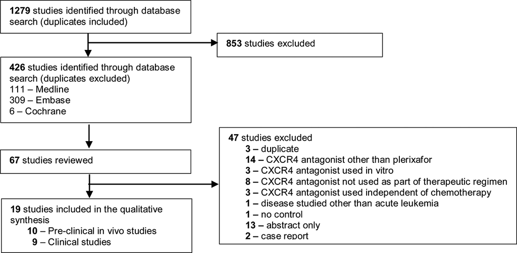

**Fig. 1.** Result of systematic search of the literature.

*H. Maganti et al.*

*Leukemia Research 97 (2020) 106442*

4

*3.6. Characteristics of clinical studies*

A total of 289 patients with acute leukemia from 9 published clinical

trials were included in our analysis (summarized in Table 5). With re-

had favorable cytogenetic profiles (cytogenetic results were not reported

in 17 patients). Most patients (n = 273, 94 %) had AML, while 9 patients

were treated for ALL, and 7 patients had myelodysplastic syndrome. The

studies enrolled patients with de novo AML (3 studies), relapsed or re-

fractory disease (4 studies) and/or a mixture of patients (2 studies). The

median ages of patients enrolled across the 9 clinical trials was 50.5

years (range, 9–73) [Table 5]. Our analysis included studies that are

Phase I (5 studies), Phase I/II (3 studies) and Phase II (1 study). All the

studies were unblinded and only two studies [21,27] contained control

cohorts. One study [27] used historical controls and one study [21]

enrolled patients receiving plerixafor in alternating treatment cycles,

providing internal controls for each patient. Six studies [22,23,26–29]

treated patients with 240 mcg/kg/day (the dose used in previous studies

of autologous hematopoietic cell mobilization prior to autologous stem

cell transplant) [32] and the remaining three studies [21,24,25],

administered higher doses, ranging from 320 to 810 mcg/kg or

6000–15000 mcg/m2.

*3.7. Clinical outcomes and scientific correlatives*

Plerixafor treatment was administered in the context of induction

therapy (2 studies), salvage therapy (4 studies), or conditioning therapy

prior to hematopoietic cell transplantation (HCT) (3 studies). Studies of

induction or salvage treatment reported complete remission rates,

however, only six out of the nine studies reported data pertaining to

relapse free survival, relapse related mortality, or overall survival

(Supplemental Table 3). In the two controlled studies, differences in

outcomes between plerixafor-treated patients and controls were not

observed. All four studies reporting on changes in leukemia cell surface

expression of CXCR4 reported significant increases following treatment

with plerixafor. CXCR4 levels and CD34<sup>+</sup>CD38<sup>−</sup>cell [21] mobilization

increased in a dose dependent manner when plerixafor is administered

**Table 1**

Summary of Pre-clinical Studies. All studies use a mouse model of leukemia and transplanted leukemia cells on Day 1 except #11, #12, and #18 on Day 0.

Study

Disease model

(Mouse

Backbone)

Source of leukemia cells

(Cells Transplanted - population)

Dose of Plerixafor – mcg/kg (doses/schedule)

Additional therapy

(dose; timing within treatment regimen)

[11]

AML

(C57Bl/6 J mice)

C1498 murine myeloid leukemia

(2 × 10<sup>6</sup>- C1498 cell line)

2500 (6 doses, 2 h pre or post chemotherapy)

**Cytarabine** (100 mg/kg/day; days 7, 9, 11)

[12]

AML

(C57Bl/6 J mice)

C1498 murine myeloid leukemia

(2 × 10<sup>6</sup>– C1498 Cell line)

2500 (2 doses/day for 7 days, 1 dose 2 h prior to AraC and

2 h after AraC)

**AraC** (100 mg/kg, days 7–13)

[13]

APL

(B6129F1)

APL cells from spleens of mCG-PML-

RAR knock in mice

(1 × 10<sup>6</sup>- mCG<sup>PR/</sup><sup>+</sup>APL cells)

5000 (4 doses, 1 h pre and 3 h post chemo d12, 13)

**Cytarabine** (500 mg/kg/day; days 12, 13)

[14]

APL

(B6129F1)

APL cells from spleens of mCG-PML-

RAR knock in mice

(1 × 10<sup>6</sup>- mCG<sup>PR/</sup><sup>+</sup>APL cells)

5000 (4 doses, 1 h pre and 3 h post chemo, or 2 h pre

radiation)

**Cytarabine** (500 mg/kg/day; days 12, 13)

**Radiation** (350 cGy; day 12)

[15]

MLL ALL

(NSG)

Human ALL samples with MLL

rearrangement

(1 × 10<sup>6</sup>– PDX expanded bulk ALL cells)

**A:** 5000 (1 dose, 4 h pre-chemo)

**B:** 5000 (6 doses, 4 h pre-chemo)

**A: Cytarabine** 100 mg/kg/d day 14)

**B: Cytarabine** 200 mg/kg/day, days 15−17

and 22−24

[16]

MLL ALL

(NSG)

Human ALL patient samples with MLL

rearrangement

(NR – Primary CD10<sup>+</sup>CD19<sup>+</sup>ALL cells)

5000 (4 doses, days 16, 23, 30, 37)

**GCSF** (2−5mcg BID; days

14,15,21,22,28,29,35,36

**Lestaurtinib** 20 mg/kg BID days 15−19,

22−26, 29−33, 26−40

[17]

Pre-B ALL/ Flt3

(SCID)

Ba/F3 pro-B lymphocytic cells with

FLT3 ITD insertion (0.5 × 10<sup>6)</sup>

10,000 (8 doses, 2 days between day 3−17)

**Cytarabine** (50 mg/kg/day; q1 week

starting on day 3)

**ID11** (0.5 mg/kg q2 weeks; starting on day

3)

[18]

Pre-B-ALL

(NSG)

Human pre-B ALL cells

(Transplanted cell numbers not

reported)

Xenograft 1809 – CD34<sup>+</sup>CD19<sup>+</sup>CD10<sup>+</sup>

Xenofraft 2032 – CD19<sup>+</sup>CD10<sup>+</sup>

**Tumor burden experiment:**

10,000 (30 doses, continuous infusion via osmotic pump

for 3 weeks)

**Survival experiment:**

10,000 (daily; days 1−43)

**Tumor burden experiment:**

• **Vincristine** (0.25 mg/kg q1 week for 3

weeks)

**Survival experiment:**

• **Vincristine** (0.05 mg/kg q1 week for 3

weeks)

[19]

Ph + B-ALL

(NSG)

Human TXL-2 cells (Ph positive B-ALL)

(1.5 × 10<sup>6</sup>- Primary CD10<sup>+</sup>CD19<sup>+</sup>ALL

cells)

10,000 (5 doses total, twice per week and given 5−6 h

prior additional therapy, starting on day ~16)

**rGel/BLyS** (2.75 mg/kg BID; twice weekly

between day 6−33)

[20]

Pre B-ALL, Ph(-) /

Ph(+)

(NSG)

pre-B ALL

(6 × 10<sup>6</sup>- transgenic mouse p190 Bcr/

Abl ALL cells)

**Ph (****þ****) ALL**

10,000 (1 dose/day for 28 days using osmotic pump)

**Ph (-) ALL**

10,000 ((1 dose/day for 28 days using osmotic pump)

**Ph(****þ****) ALL**

• **Nilotinib** (60 mg/kg/day; days 17–28)

**Ph(-) ALL**

• **Vincristine** (0.5 mg/kg/day; days 12–40)

• **Dexamethasone** (10.5 mg/kg/day; days

12–40)

• **L-asparaginase** (1500IU/kg/day; days

12–40)

AML = acute myeloid leukemia, APL = acute promyelocytic leukemia, ALL = acute lymphoblastic leukemia, ALI = allogeneic lymphocyte infusion, IP = intraperi-

toneal, GFP = green fluorescent protein, NR = not reported, AraC = cytarabine, MLL = mixed lineage leukemia, NSG – non-obsese severe combined immunodeficient

gamma (mouse strain), Ph – Philadelphia chromosome, t(9;22), PML-RAR = promyelocytic leukemia – retinoic acid receptor alpha, ID11: TGF-beta-Neutralizing

Antibody, rGel/BLyS: is a toxin-cytokine fusion protein used for selective killing of malignant B-cells expressing receptors for B-cell Activating Factor (BAFF/BLyS)

by receptor-targeted delivery of the toxin, Gelonin.

*H. Maganti et al.*

*Leukemia Research 97 (2020) 106442*

5

to patients (Supplementary Table 4). All studies measured blast mobi-

lization within the peripheral blood. As summarized in Supplementary

Table 4, most studies report peak mobilization of blasts between 4−6 h

post administration of plerixafor. Flow cytometry was used to quantify

blast mobilization and the expression (reported as mean flourescence

intensity) of the CXCR4 receptor.

*3.8. HCT studies*

Three studies used plerixafor as part of conditioning therapy prior to

HCT for patients with AML, ALL and myelodysplastic syndrome

(Table 5). While one study [28] does not provide the cytogenetics of the

patients enrolled in the clinical trial, they report on pediatric patients

undergoing second allogeneic HCT for relapsed disease Two studies [27,

29] provide cytogenetics and/or remission status of the patients enrolled

(Table 5). While one study [27] was phase I/II, the other two studies [28,

29] were Phase I. The phase I/II study [27] used historical controls for

comparison. All three studies administered 240 mcg/kg/day of plerix-

afor with each dose, however the timing within regimens varied

(Table 5). The median ages of patients enrolled in the transplantation

studies was 49 years (range: 9–54). The median complete remission

status at time of transplant across the three studies was 50 % (range

17–52.5) (Supplementary Table 3). The median relapse related mor-

tality at last follow-up across the three studies was 33 % (range 17–84)

(Supplementary Table 3). While plerixafor did not impact rates of initial

engraftment, relapse or survival in the studies compared with control

groups, complete myeloid donor chimerism at day +30 and day +100

was increased in the treatment group in one study [27].

**Table 2**

Assessment of tumor burden and overall survival in pre-clinical studies.

Ref

Method used to assess tumour

burden

Timing of assessment

Tumour burden –

Control

Tumour burden –

Intervention

Median OS Control -

(days)

Median OS

Treatment - (days)

P value

[11]

**H****&****E staining**

d ~25−30 post

leukemia

**BM:** 50.4 ± 4.5%

**BM:** 36.1 ± 4.4%

NR

NR

NR

**Liver:** 58.7 ±

2.9%

**Liver:** 23.1 ± 2.8%

**Spleen:** 47.4 ±

3.5%

**Spleen:** 26.0 ± 2.7%

[12]

**H****&****E staining**

Upon humane endpoint

until d 26

**BM:** 60.7 ± 5.1%

**BM:** 31.1 ± 11.9%

~23†

~24.1†

NS

**Liver:** 50.2 ±

4.2%

**Liver:** 39.2 ± 5%

**Spleen:** 51.8 ±

3.7%

**Spleen:** 43%± 7%

[13]

**BLI**

D 24 post leukemia

**~3**†

**~12**†

~22†

~27†

NR

NR

NR

NR

~23†

~30†

*<*0.001

[14]

NR

NR

NR

NR

~17†

~21†

*<*0.05

NR

NR

NR

NR

~27†

~29†

NS

[15]

**Flow cytometry**

*(fold change in human CD49*+

*blasts)*

d 28

**BM** ~0.8†

**BM** ~0.6†

NR

NR

NR

**Blood** ~1†

**Blood** ~0.9†

**Spleen** ~1.4†

**Spleen** ~0.5†

**BM** ~0.5†

**BM** ~0.3†

NR

NR

NR

**Blood** ~0.6†

**Blood** ~0.5†

**Spleen** ~0.3†

**Spleen** ~0.2†

[16]

**Flow cytometry** *(% BM human/*

*murine CD45*+ *cells)*

10 weeks after

treatment

**Patient 1** ~65%†

**Patient 1** ~11.5%†

NR

NR

NR

**Patient 2**~75%†

**Patient 2** ~36%†

[17]

**BLI**

d 13 & 17

**~3.5**†

**~2**†

19 (range 16−21)

19 (range 17−22)

NS

[18]

**Flow cytometry** *(% human*

*CD45*+*/CD19* + *ALL cells)*

3 weeks after treatment

**BM** ~84%†

**BM** ~3%†

**Xenograft 1809**

**Blood** ~40%†

**Blood** ~10%†

60 (CI 57−63)

97 (CI 89−105)

*<*0.002

**Spleen** ~10%†

**Spleen** ~30%†

**BM** ~48%†

**BM** ~9%†

**Xenograft 2032**

**Blood** ~40%†

**Blood** ~10%†

72 (CI 66−78)

126 (CI 94−158)

0.027

**Spleen** ~10%†

**Spleen** ~30%†

[19]

**Flow cytometry** *(% human*

*CD19*+*/CD10* + *ALL cells)*

d 46

**BM** ~48%†

**BM** ~11%†

NR

NR

NR

**Blood** ~0%†

**Blood** ~0%†

**Spleen** ~60%†

**Spleen** ~15%†

[20]

NR

NR

NR

NR

~27†

~35†

0.047

NR

NR

NR

NR

54

61.5

0.015

BM = bone marrow, BLI = bioluminescence imaging, photons/sec x10<sup>7</sup>; BM = bone marrow; VDL = combination of vincristine, dexamethasone, L-asparaginase, NR =

not reported, OS = overall survival, †Data extracted from figures in the report. ††Dosing details are provided in Table 1.

*Study included multiple experimental arms, the control group pertaining to experiment that generated the outcomes listed is shown here. **Mean overall survival (in

days).

**H****&****E staining** *(visual estimation of blasts %).*

**Table 3**

Forrest Plot analysis assessing the change in peripheral blast percentages after treatment in the control and treatment groups of pre-clinical studies.

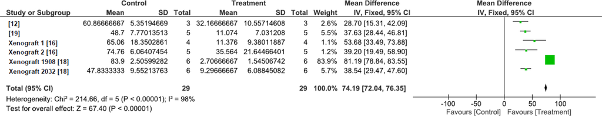

*H. Maganti et al.*

*Leukemia Research 97 (2020) 106442*

6

*3.9. Safety*

Safety and adverse events are summarized for all clinical studies in

Supplementary Table 3. Multiple grade 3, grade 4 and grade 5 toxicities

were reported. The adverse events were expected given the age of the

patients and concomitant cytotoxic chemotherapy agents that were

administered. A total of two patients had dose limiting toxicity; one due

to renal insufficiency that was not clearly attributed to plerixafor at a

dose of 810 mcg/kg [21], and the second had grade 4 neutropenia

was not clearly related to plerixafor [22]. None of the grade 3 or 4

adverse events were attributable to plerixafor. The most common grade

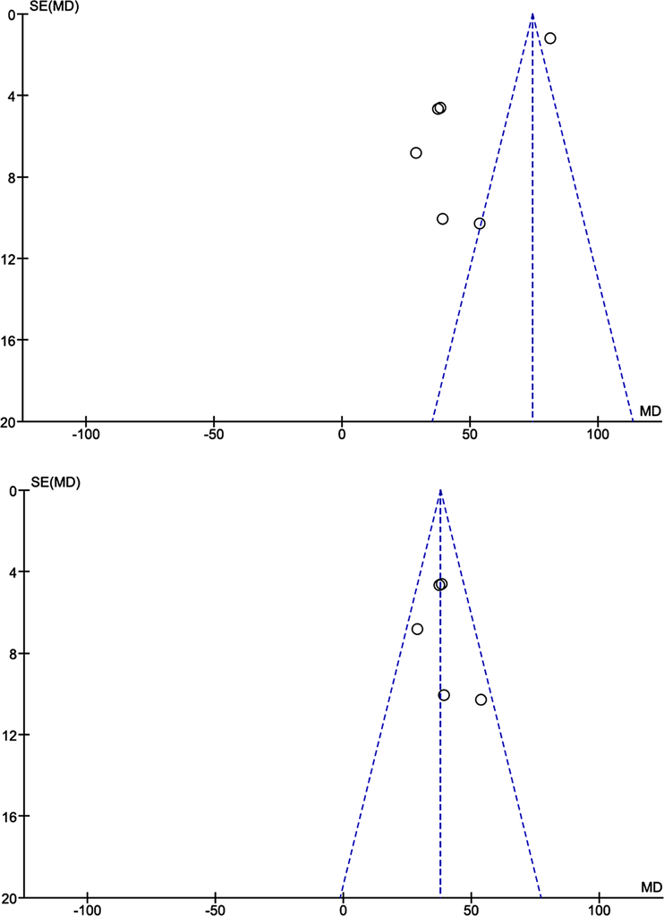

**Fig. 2.** (A) Funnel Plot analysis of pre-clinical studies of mice with Acute Leukemia – Control Vs Treatment. Difference in the means of blast % between Control and

Treatment group are plotted against the standard error.

**Table 4**

Forrest Plot analysis assessing the mean difference in overall survival in pre-clinical studies.

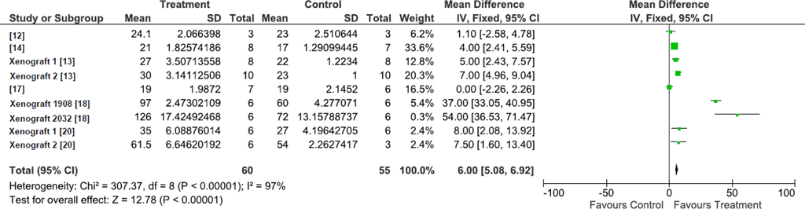

*H. Maganti et al.*

*Leukemia Research 97 (2020) 106442*

7

1–2 toxicities attributed to plerixafor included gastrointestinal com-

plaints such as nausea, vomiting, and diarrhea. Except for 1 patient

(described above), there were no delays in engraftment and/or recovery

of blood counts following treatment. None of the studies reported sig-

nificant leukostasis due to peripheral mobilization of blasts, however 6

of the 8 studies specifically excluded patients with a high baseline white

blood cell count greater than 20−50 × 10<sup>9</sup>/L.

**4. Discussion**

Our systematic review of preclinical and clinical studies provides a

summary of evidence that highlights the potential role of using plerix-

afor in combination with chemotherapy for the management of acute

leukemia. Plerixafor inhibits the binding of SDF1α to CXCR4, disrupting

the interaction between leukemia cells and the bone marrow stroma,

and was given to induce the mobilization of leukemia cells into the

circulation and enhance their elimination by cytotoxic chemotherapy.

The preclinical animal studies summarized in this systematic review

confirmed that leukemia cell mobilization can be achieved with a sig-

nificant reduction of leukemic burden and improved animal survival

across a range of strategies that were used to induce leukemia in mice,

including the use of gene knock-in methods, murine leukemia cell lines,

and the use of primary patient samples transplanted into immunosup-

pressed mice to induce AML and ALL. In addition, clinical studies

demonstrated the safety and feasibility of using plerixafor in combina-

tion with induction chemotherapy, salvage treatment for relapsed or

refractory leukemia, and as part of the conditioning therapy prior to

HCT.

The role of mouse genetics in animal leukemia models may have

impacted treatment outcomes in the studies included in our analysis. For

example, unlike C57Bl/6 J mice, NSG and SCID mice have impaired

natural killer, macrophage, B cell and T cell function that enables better

engraftment of human cells [33]. Furthermore, the scid mutation

(Prkdc<sup>scid</sup>) found within SCID and NSG mice make them highly

**Table 5**

Summary of Clinical Studies.

Ref

Disease

Therapy

Plerixafor dose mcg/kg/

day

(timing in regimen)*

Additional treatment

intervention

Control

group

Sample size

(n)**

Cytogenetic

Risk

(Adv/Int/

Fav)

Median age,

years (range)

Median

follow up

Months

(range)

[21]

AML, de

novo

Induction

320, 540, or 810

(d 1−5)

**Decitabine** (20 mg/m2 IV

d 1−10)

Yes†

69

37/32/0

73 (56−87)

9.9

(5.4–24.8)

[22]

AML, de

novo

Induction

240 (7 patients)

and 320 (3 patients)

**GCSF** (5 ug/kg days 1–10)

**Daunorubicin** (60 mg/m<sup>2</sup>

on day 1−3)

**Cytarabine** (500 mg/m<sup>2</sup>

on day 1−3)

No

10

1/4/3

NR = 2

49 (36−64)

NR

[23]

AML, rel/

ref

Salvage

240

(d 0−5)

**MEC**

No

52

16/29/7

52 (18−70)

19.8 (NR)

[24]

AML, B-

ALL, rel/ref

Salvage

6000, 9000, 12000, or

15,000 mcg/m2(d 1

−5)

**Cytarabine** (1 g/m2 IV

q12 h days 1–5)

**Etoposide** (150 mg/m2 IV

days 1–5)

No

18

12/3/3

AML, 13

(3−17)ALL 14

(12

−21)

NR

[25]

AML, rel/

ref

Salvage

750

(d 3−8)

**MEC** **þ** **GCSF** (10mcg/kg

SC days 1–8)

No

35

13/19/3

56 (29−70)

34.6 (NR)

[26]

AML, rel/

ref

Salvage

240

(d 1−4)

**FLAG-Ida**

No

41

19/19/2

NR = 1

52 (18−64)

21 (6−38)

[27]

AML, MDS

HCT

240

(d -7 to -4 of

conditioning)

**Busulfan** (130 mg/m2 IV

days -6 to -3)

**fludarabine** (40 mg/m2

IV days -6 to -3)

**GCSF** (10mcg/kg/d SC

days -9 to -4)

**ATG** if unrelated donor

Yes***

40

16/22/2

54 (25−65)

11.6

(0.5−36.4)

[28]

AML, ALL,

rel

HCT

240

(d -4 for 1−3 d with

conditioning)

**fludarabine** (30 mg/m2

IV days -9 to -5)

**thiotepa** (5 mg/kg/dose

IV q12 h on day -4)

**melphalan** (70 mg/m2 IV

days -3 and -2)

**rabbit ATG** (3 mg/kg/dose

IV day -3 to -1

No

12

NR

9 (6−15)

10.9

(0.5−24.7)

[29]

AML, de

novo

HCT

240

(d -4 to -2 of

conditioning)

**Fludarabine** (50 mg/m2 –

1–4)

**Busulfan** (3.2 mg/kg/day

on day 1–4)

No

12

1/9/2

49 (38−55)

67 (53−82)

NR = not reported, Adv = Adverse, Int = Intermediate, Fav = Favorable.

Given 4–8 h prior to chemo in most studies.

MEC, Mitoxantrone (8 mg/m2 IV days 1–5), Etoposide (100 mg/m2 IV days 1–5), Cytarabine (1 g/m2 IV days.1–5).

FLAD-Ida, Fludarabine (30 mg/m2 IV days 1–4), Cytarabine (2 g/m2 IV days 1–4), GCSF (5mcg/kg SC days 1–4), Idarubicin (10 mg/m2 IV days.1–3).

GCSF, granulocyte colony-stimulating factor.

ATG, antithymocyte globulin.

HCT, hematopoietic cell transplantation.

Rel : Relapse.

Ref: refractory.

* In studies that reported phase 1 and phase 2 data, the recommended phase 2 dose is reported here.

** In studies that reported phase 1 and phase 2 data the number of patients in the phase 2 component is reported here.

*** Historical control group was treated with same regimen of busulfan, fludarabine, GCSF, +/- ATG, but did not receive AMD3100.

† plerixafor was administered during alternating treatment cycles, therefore each patient served as his/her own control for correlative scientific studies.

*H. Maganti et al.*

*Leukemia Research 97 (2020) 106442*

8

susceptible to high dose radiation and chemotherapy drugs such as

cytarabine [34]. The pre-clinical studies summarized within our sys-

tematic review used a variety of genetic strains that included NSG, SCID

and C57Bl/6 J which may not translate into similar treatment responses

or tolerance in humans. Furthermore, we recognize that acute leukemia

is a heterogenous disease and not all leukemic cells have the capacity to

engraft

and

induce

leukemia

when

transplanted

into

genetically-modified animals. While all the studies transplanted

leukemic cells into mice, different cell numbers were transplanted and

the timing of treatment with plerixafor varied significantly between

studies. Furthermore, one study [15] used a secondary transplant model

that significantly enriched for leukemia initiating clones (LICs). Inter-

estingly, none of the studies provided information regarding the per-

centage of leukemic blasts observed within the peripheral blood at the

time of treatment. Taken together, these observations suggest that mice

cohorts between studies had different proportions of LICs and differ-

ences in response to treatment may be partly explained by these genetic

host factors. Our pooled analysis revealed a high degree of heterogeneity

observed within treatment outcomes, including *in vivo* tumor burden

and overall survival. The observed heterogeneity associated with our

pooled estimate of overall survival was likely due to differences in the

number of engrafted LICs, whereas heterogeneity observed within the

reduction of tumor burden was likely due to differences in specific cell

populations transplanted into the mice. For instance, all xenografts

analyzed for tumor burden were transplanted with human CD10<sup>+</sup>CD19<sup>+</sup>

ALL cells, and one xenograft model that accounted for 93 % of the

heterogeneity was transplanted with human CD34<sup>+</sup>CD19<sup>+</sup>CD10<sup>+</sup>cells

which may have been more restricted in the number of LICs transplanted

into mice, yielding more favorable responses. A consideration for future

studies would be to select mice with similar levels of leukemic burden,

either by transplanting similar cell populations (enriched for LICs) from

human leukemia samples into mice or selecting transplanted mice that

display a similar degree of LIC engraftment. Utilizing mice from sec-

ondary transplants that have developed leukemia from LICs is another

consideration that could enhance consistency amongst the animal

models used in preclinical leukemia research.

The use of human leukemia samples compared to cell lines or murine

leukemia cells introduces additional significant heterogeneity albeit

greater clinical relevance. Clinical studies enrolling patients with leu-

kemia further augments heterogeneity in treatment responses. This may

contribute to overestimation of favorable outcomes in preclinical

studies. In our systematic review of clinical trials that investigated the

therapeutic benefit of using plerixafor in combination with standard

therapy for the management of acute leukemia, we observed that the

majority of studies addressed AML. The lack of control cohorts within

most of these early phase clinical trials precluded us from performing a

meta-analysis to measure the additive benefit of using plerixafor in

combination with standard regimens. Within the two studies [21,27]

that included controls, no difference in overall survival was reported,

however, followup was limited in these studies and disease risk was

variable and may have dominated the determination of outcomes. While

there is potential concern that plerixafor may mobilize excessive

numbers of leukemic blasts into the peripheral blood, no study reported

instances of leukostasis, however patients enrolled in the studies had

median baseline WBC less than 20 × 10/L which may have allowed

selection of patients at lower risk of developing this complication.

Moreover, the risk of bone marrow aplasia or delayed bone marrow

reconstitution post chemotherapy due to destruction of mobilized

normal HSCs by chemotherapy was not observed in the clinical studies.

Overall, plerixafor was well tolerated, and the main side effects attrib-

utable to plerixafor were gastrointestinal. The safety findings of these

clinical studies are in keeping with those reported in the phase 3 studies

using plerixafor as mobilization therapy [32].

AML is a heterogeneous disease in which the characteristics of LICs

drive leukemic progression. A recent preclinical study has shown that

targeting LICs enriched within the CD34<sup>+</sup>CD38<sup>−</sup>population can greatly

reduce relapse and attenuate AML progression [35]. The strategy behind

using plerixafor for the management of AML is to mobilize HSPCs/LICs

from their protective niche in combination with induction chemo-

therapy regimens to target the mobilized cells. For this strategy to work,

it is essential to identify the optimal dose of plerixafor required to

mobilize sufficient numbers of LICs within the pool of CD34<sup>+</sup>CD38<sup>−</sup>

cells from the bone marrow of a patient with AML [21]. Surprisingly,

only one clinical study [21] reported the mobilization of CD34<sup>+</sup>CD38<sup>−</sup>

cells upon the administration of plerixafor. The remaining studies

measured only fold changes in blast or white blood cell (WBCs) mobi-

lization. Considering blasts (CD45<sup>+</sup>or CD45<sup>+</sup>CD33<sup>+</sup>) and WBCs have

high expression of CXCR4 receptor in comparison to CD34<sup>+</sup>CD38<sup>−</sup>cells,

one cannot assume that the mobilization of WBCs and/or blasts gua-

rantees the mobilization of CD34<sup>+</sup>CD38<sup>−</sup>cells in sufficient numbers. To

assess the efficacy of chemosensitization of LICs with plerixafor, clinical

studies need to assess the degree of CD34<sup>+</sup>CD38<sup>−</sup>mobilization with

CXCR4 antagonists to ensure LICs are being mobilized from bone

marrow niches. One study [21] reported that in an elderly patient cohort

(median age 73) administering 810 mcg/kg/day of plerixafor was able

to mobilize the most number of LICs from the bone marrow niche, and

that the mobilizing effect of plerixafor was highly significant among

clinical responders versus non-responders. Furthermore, the same study

[21] reported that within responders, plerixafor forced CD34<sup>+</sup>CD38<sup>−</sup>

LICs into cell cycle. Since cytotoxic induction therapy targets cycling

cells, it may be worth testing higher doses of plerixafor in combination

with induction therapy within younger AML patient cohorts.

Recent single cell RNA-sequencing studies have demonstrated that

CXCR4 expression varies significantly between hematopoietic stem and

progenitor cells (HSPCs) [36]. Considering plerixafor binds to the

CXCR4 receptor, it is unlikely that HSPCs with low levels of CXCR4 are

mobilized by plerixafor to the same extent as high-expressing HSPCs.

Variable expression of CXCR4 by LICs is also anticipated. One study [21]

reported that patients with leukemia responding to decitabine treatment

contained variable levels of cell surface CXCR4 and that plerixafor only

mobilized CD34<sup>+</sup>CD38<sup>−</sup>LICs in patients with high levels of CXCR4,

leading to LIC exhaustion. Several studies [23–25,27] have also reported

that administration of chemotherapy or plerixafor can result in

increased CXCR4 expression. Therefore, pre-screening for CXCR4

expression levels within CD34<sup>+</sup>CD38<sup>−</sup>cells isolated from bone marrow

aspirates of AML patients at diagnosis may aid clinicians in identifying

target patient populations that will respond most favorably to plerixafor.

Allogenic HCT is potentially curative for AML. Three studies [27–29]

administered plerixafor as part of conditioning therapy prior to HCT.

One study [27] reported that administering plerixafor and GCSF as part

of conditioning therapy followed by HCT had no benefits. In terms of

rates of achieving donor chimerism after transplantation, this study [27]

used historical controls that reported lymphoid chimerism, whereas the

treatment cohort reported myeloid chimerism. The observation that

rates of GvHD were lower in the treatment group compared to historical

patients is interesting. It is possible that risk factors for GVHD, including

HLA matching were improved in the more recent treatment group,

however, GCSF has been shown to modulate both the microenvironment

and T cells in a way that promotes the expansion of T regulatory cells

and plerixafor can mobilize T regulatory cells out of the protective bone

marrow niche [37,38]. Taken together, the combination of GCSF and

plerixafor may attenuate GvHD and should be addressed in future

studies. Moreover, GCSF has been shown to affect the bone marrow

niche making it hospitable for HSC engraftment in the context of AML

and allogenic HCT [39]. Moving forward more studies need to be done

where GCSF and plerixafor are administered separately or perhaps at

different doses.

In conclusion, our systematic review provides an unbiased and

robust summary of the preclinical and clinical experience using plerix-

afor in the management of acute leukemia and has identified several

aspects of study design that should be considered to accelerate further

progress in our understanding of how plerixafor can be used to improve

*H. Maganti et al.*

*Leukemia Research 97 (2020) 106442*

9

outcomes for patients with acute leukemia. Our analysis of preclinical

studies confirms that leukemia cells can be mobilized from the protected

bone marrow environment and in combination with cytotoxic treat-

ment, plerixafor is associated with a marked reduction in tumor burden

and improved survival of animals. This insight can be used to rationalize

a greater focus on clinical studies. Our summary of clinical studies

demonstrates relative safety and feasibility of combining plerixafor with

conventional therapy for acute leukemia, including induction regimens

and salvage treatment, providing further support for continued study of

plerixafor in the clinical setting. Moreover, plerixafor can be included in

the conditioning regimen prior to HCT. While clinical outcomes were

not clearly improved with plerixafor, larger studies in more patients

with higher risk disease and/or in patients with leukemia that have high

CXCR4 expression appear worthwhile to assess the potential impact on

reducing relapse. Identifying patients and/or creating animal models of

leukemia using LICs that have high levels of surface CXCR4 may be

worthwhile and use of higher doses of plerixafor appear worthy of future

study. Given the modest benefits observed in early clinical studies

identified in our analysis, it is possible that the significant clinical

benefits from plerixafor may not be realized and it remains premature to

consider plerixafor part of standard treatment for acute leukemia

**Declaration of Competing Interest**

The authors report no declarations of interest.

**Acknowledgements**

We acknowledge input from Dr. Clinton Campbell (McMaster Uni-

versity, Canada) for helpful discussions regarding the design of the

study. The authors all contributed to the design and conduct of the

study, and/or the drafting and final approval of the manuscript.

**Appendix A. Supplementary data**

Supplementary material related to this article can be found, in the

online version, at doi:https://doi.org/10.1016/j.leukres.2020.106442.

**References**

[1] S. Horibata, et al., Heterogeneity in refractory acute myeloid leukemia, Proc. Natl.

Acad. Sci. U. S. A. 116 (21) (2019) 10494–10503.

[2] T. Terwilliger, M. Abdul-Hay, Acute lymphoblastic leukemia: a comprehensive

review and 2017 update, Blood Cancer J. 7 (6) (2017) e577.

[3] B. Patel, et al., Mouse xenograft modeling of human adult acute lymphoblastic

leukemia provides mechanistic insights into adult LIC biology, Blood 124 (1)

(2014) 96–105.

[4] J.E. Dick, Acute myeloid leukemia stem cells, Ann. N. Y. Acad. Sci. 1044 (2005)

1–5.

[5] M. Houshmand, et al., Bone marrow microenvironment: the guardian of leukemia

stem cells, World J. Stem Cells 11 (8) (2019) 476–490.

[6] H. Zhao, et al., CXCR4 over-expression and survival in cancer: a system review and

meta-analysis, Oncotarget 6 (7) (2015) 5022–5040.

Cancer Res. 64 (8) (2004) 2817–2824.

[8] B.S. Cho, H.J. Kim, M. Konopleva, Targeting the CXCL12/CXCR4 axis in acute

myeloid leukemia: from bench to bedside, Korean J. Intern. Med. 32 (2) (2017)

248–257.

[9] Y. Chen, et al., CXCR4 downregulation of let-7a drives chemoresistance in acute

myeloid leukemia, J. Clin. Invest. 123 (6) (2013) 2395–2407.

[10] A.P. Nademanee, et al., Plerixafor plus granulocyte colony-stimulating factor

versus placebo plus granulocyte colony-stimulating factor for mobilization of CD34

(+) hematopoietic stem cells in patients with multiple myeloma and low peripheral

blood CD34(+) cell count: results of a subset analysis of a randomized trial, Biol.

Blood Marrow Transplant. 18 (10) (2012) 1564–1572.

[11] A.R. Han, et al., A CXCR4 antagonist leads to tumor suppression by activation of

immune cells in a leukemia-induced microenvironment, Oncol. Rep. 34 (6) (2015)

2880–2888.

[12] H.S. Hwang, et al., Enhanced anti-leukemic effects through induction of

immunomodulating microenvironment by blocking CXCR4 and PD-L1 in an AML

mouse model, Immunol. Invest. 48 (1) (2019) 96–105.

[13] B. Nervi, et al., Chemosensitization of acute myeloid leukemia (AML) following

mobilization by the CXCR4 antagonist AMD3100, Blood 113 (24) (2009)

6206–6214.

[14] P. Macanas-Pirard, et al., Bone marrow stromal cells modulate mouse ENT1

activity and protect leukemia cells from cytarabine induced apoptosis, PLoS One 7

(5) (2012) e37203.

[15] E.A. Sison, et al., Plerixafor as a chemosensitizing agent in pediatric acute

lymphoblastic leukemia: efficacy and potential mechanisms of resistance to CXCR4

inhibition, Oncotarget 5 (19) (2014) 8947–8958.

[16] E.A. Sison, et al., MLL-rearranged acute lymphoblastic leukaemia stem cell

interactions with bone marrow stroma promote survival and therapeutic resistance

that can be overcome with CXCR4 antagonism, Br. J. Haematol. 160 (6) (2013)

785–797.

[17] Y. Tabe, et al., TGF-beta-Neutralizing antibody 1D11 enhances cytarabine-induced

apoptosis in AML cells in the bone marrow microenvironment, PLoS One 8 (6)

(2013) e62785.

[18] R. Welschinger, et al., Plerixafor (AMD3100) induces prolonged mobilization of

acute lymphoblastic leukemia cells and increases the proportion of cycling cells in

the blood in mice, Exp. Hematol. 41 (3) (2013), p. 293-302 e1.

[19] R. Parameswaran, et al., Treatment of acute lymphoblastic leukemia with an rGel/

BLyS fusion toxin, Leukemia 26 (8) (2012) 1786–1796.

[20] M. Yu, et al., AMD3100 sensitizes acute lymphoblastic leukemia cells to

chemotherapy in vivo, Blood Cancer J. 1 (4) (2011) e14.

[21] G.J. Roboz, et al., Phase I trial of plerixafor combined with decitabine in newly

diagnosed older patients with acute myeloid leukemia, Haematologica 103 (8)

(2018) 1308–1316.

[22] M. Heiblig, et al., A phase 1 study of chemosensitization with plerixafor plus G-CSF

in adults with relapsed acute myeloid leukemia, Leuk. Res. 72 (2018) 7–11.

[23] G.L. Uy, et al., A phase 1/2 study of chemosensitization with the CXCR4 antagonist

plerixafor in relapsed or refractory acute myeloid leukemia, Blood 119 (17) (2012)

3917–3924.

[24] T.M. Cooper, et al., A phase 1 study of the CXCR4 antagonist plerixafor in

combination with high-dose cytarabine and etoposide in children with relapsed or

refractory acute leukemias or myelodysplastic syndrome: a Pediatric Oncology

Experimental Therapeutics Investigators’ Consortium study (POE 10-03), Pediatr.

Blood Cancer 64 (8) (2017).

[25] G.L. Uy, et al., A phase 1/2 study of chemosensitization with plerixafor plus G-CSF

in relapsed or refractory acute myeloid leukemia, Blood Cancer J. 7 (3) (2017)

e542.

[26] D. Martinez-Cuadron, et al., A phase I-II study of plerixafor in combination with

fludarabine, idarubicin, cytarabine, and G-CSF (PLERIFLAG regimen) for the

treatment of patients with the first early-relapsed or refractory acute myeloid

leukemia, Ann. Hematol. 97 (5) (2018) 763–772.

[27] M. Konopleva, et al., Leukemia cell mobilization with G-CSF plus plerixafor during

busulfan-fludarabine conditioning for allogeneic stem cell transplantation, Bone

Marrow Transplant. 50 (7) (2015) 939–946.

[28] A. Srinivasan, et al., Phase I study of the safety and pharmacokinetics of plerixafor

in children undergoing a second allogeneic hematopoietic stem cell transplantation

for relapsed or refractory leukemia, Biol. Blood Marrow Transplant. 20 (8) (2014)

1224–1228.

[29] F.V. Michelis, et al., Mobilization of leukemic cells using plerixafor as part of a

myeloablative preparative regimen for patients with acute myelogenous leukemia

undergoing allografting: assessment of safety and tolerability, Biol. Blood Marrow

Transplant. 25 (6) (2019) 1158–1163.

[30] D. Moher, et al., Preferred reporting items for systematic reviews and meta-

analyses: the PRISMA statement, PLoS Med. 6 (7) (2009) e1000097.

[31] V.C. Henderson, et al., Threats to validity in the design and conduct of preclinical

efficacy studies: a systematic review of guidelines for in vivo animal experiments,

PLoS Med. 10 (7) (2013) e1001489.

[32] J.F. DiPersio, et al., Phase III prospective randomized double-blind placebo-

controlled trial of plerixafor plus granulocyte colony-stimulating factor compared

with placebo plus granulocyte colony-stimulating factor for autologous stem-cell

mobilization and transplantation for patients with non-Hodgkin’s lymphoma,

J. Clin. Oncol. 27 (28) (2009) 4767–4773.

[33] S.P. McDermott, et al., Comparison of human cord blood engraftment between

immunocompromised mouse strains, Blood 116 (2) (2010) 193–200.

[34] K.A. Biedermann, et al., Scid mutation in mice confers hypersensitivity to ionizing

radiation and a deficiency in DNA double-strand break repair, Proc. Natl. Acad. Sci.

U. S. A. 88 (4) (1991) 1394–1397.

[35] H.B. Maganti, et al., Targeting the MTF2-MDM2 Axis Sensitizes refractory acute

myeloid leukemia to chemotherapy, Cancer Discov. 8 (11) (2018) 1376–1389.

[36] P. van Galen, et al., Single-cell RNA-Seq reveals AML hierarchies relevant to

disease progression and immunity, Cell 176 (6) (2019), p. 1265-1281 e24.

[37] L.S. Kean, et al., Significant mobilization of both conventional and regulatory T

cells with AMD3100, Blood 118 (25) (2011) 6580–6590.

[38] L. Zou, et al., Bone marrow is a reservoir for CD4+CD25+ regulatory T cells that

traffic through CXCL12/CXCR4 signals, Cancer Res. 64 (22) (2004) 8451–8455.

[39] I.G. Winkler, et al., Hematopoietic stem cell mobilizing agents G-CSF,

cyclophosphamide or AMD3100 have distinct mechanisms of action on bone

marrow HSC niches and bone formation, Leukemia 26 (7) (2012) 1594–1601.

*H. Maganti et al.*